# LobsterReport

Anna PerezWelter and Jamie K. Miller

11/14/2018

### 1. Lobster abundance and fishing pressure (2012-2017)

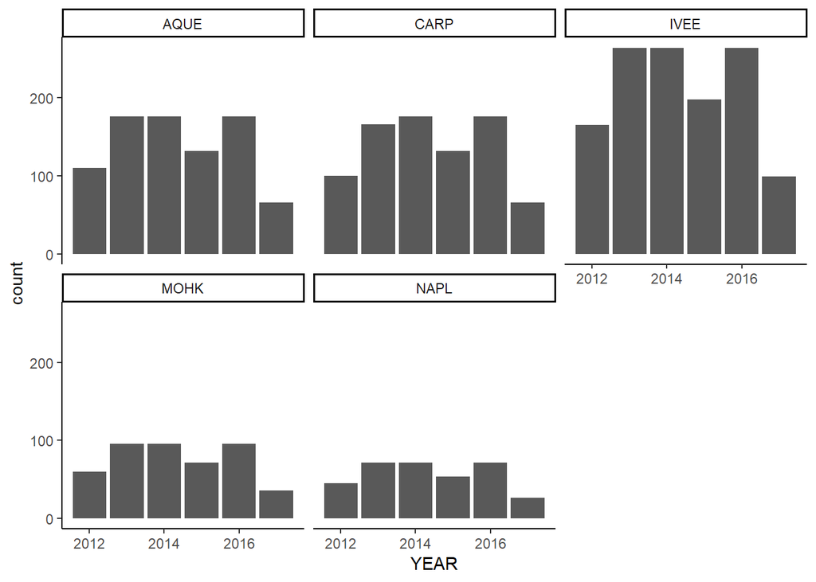

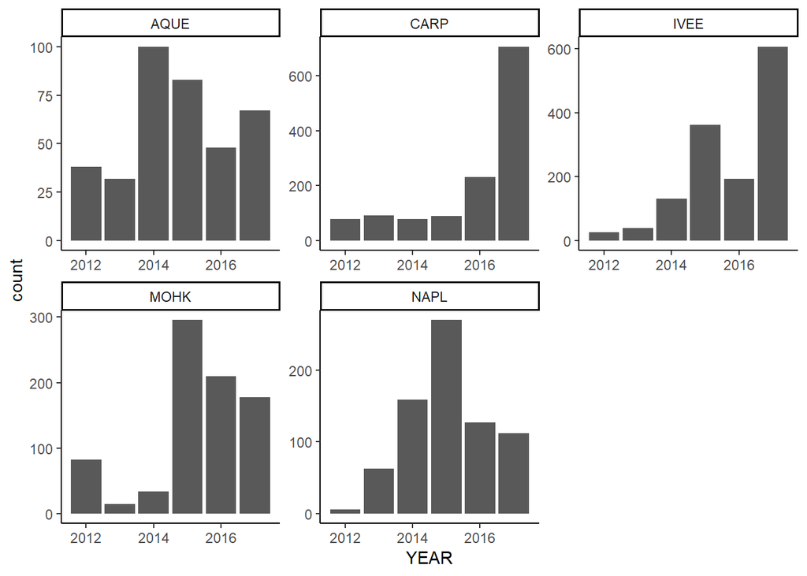

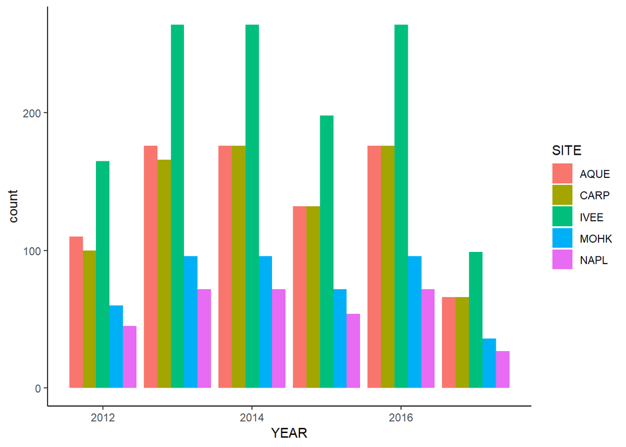

```r
### 1. Lobster abundance and fishing pressure (2012-2017)
# Second attempt at useful graph

trap_graph_2 <- ggplot(traps_summary, aes(x = YEAR, y = count)) +
                       geom_bar(position = position_dodge(), stat = "identity", aes(fill = SITE)) +
  theme_classic()
trap_graph_2
```

```r
lobster_graph_2 <- ggplot(lobster_summary, aes(x = YEAR, y = count)) +
                      geom_bar(position = position_dodge(),
                               stat = "identity", aes(fill = SITE)) +
  scale_fill_manual(
values = c("skyblue", "royalblue","steelblue", "blue", "navy"),
limits = c("AQUE", "CARP", "IVEE", "MOHK", "NAPL"), breaks =c("AQUE", "CARP", "IVEE", "MOHK", "NAPL"),
name = "Site", labels = c("AQUE", "CARP", "IVEE", "MOHK", "NAPL"))
  theme_classic()
```

[output not shown]

[output cut: 334 more lines]

[output not shown]

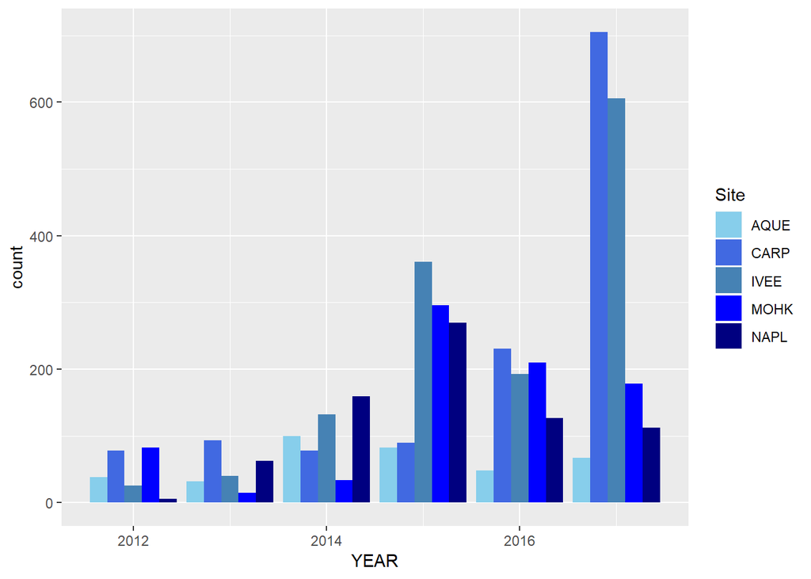

```r
lobster_graph_2
```

### 2. Compare mean lobster size across five sites in 2017

**Table 1. Summarized lobster carapace length at five sites in 2017.** Median, maximum, and mean lobster carapace length (mm) for sites AQUE, CARP, IVEE, MOHK, and NAPL in Santa Barbara County in 2017 (n = 1,668). Data were collected every two to four weeks from October to March by the Santa Barbara Coastal Long Term Ecological Research Project (SBC LTER).

| Site | Lobster Carapace Length (mm) Median | Lobster Carapace Length (mm) Max | Lobster Carapace Length (mm) Mean | Lobster Carapace Length (mm) SD | Lobster Carapace Length (mm) n |
| --- | --- | --- | --- | --- | --- |
| AQUE | 75 | 105 | 73.9 | 11.9 | 67 |
| CARP | 73 | 115 | 72.2 | 13.2 | 705 |
| IVEE | 70 | 150 | 71.5 | 14.3 | 606 |
| MOHK | 71 | 95 | 72.0 | 9.3 | 178 |
| NAPL | 78 | 105 | 76.2 | 11.4 | 112 |

```
##               Df Sum Sq Mean Sq F value Pr(>F)
## SITE           4   2355   588.6   3.424 0.0085 **
## Residuals   1663 285871   171.9
## ---
## Signif. codes:  0 '***' 0.001 '**' 0.01 '*' 0.05 '.' 0.1 ' ' 1
```

```
##   Tukey multiple comparisons of means
##     95% family-wise confidence level
##
## Fit: aov(formula = SIZE ~ SITE, data = size_2017)
##
## $SITE
##                 diff         lwr      upr     p adj
## CARP-AQUE -1.6657352 -6.24294710 2.911477 0.8582355
## IVEE-AQUE -2.4433772 -7.05292315 2.166169 0.5968998
## MOHK-AQUE -1.8955224 -7.02720717 3.236162 0.8514711
## NAPL-AQUE  2.3366205 -3.19311600 7.866357 0.7775633
## IVEE-CARP -0.7776420 -2.76097123 1.205687 0.8216104
## MOHK-CARP -0.2297872 -3.23309697 2.773523 0.9995765
## NAPL-CARP  4.0023556  0.36042398 7.644287 0.0228728
## MOHK-IVEE  0.5478548 -2.50450730 3.600217 0.9882889
## NAPL-IVEE  4.7799976  1.09751057 8.462485 0.0037001
## NAPL-MOHK  4.2321429 -0.08607271 8.550358 0.0579286
```

Lobster carapace length significantly differs in at least two sites in 2017 (F(4,1663) = 3.42, $p$ = 0.0085, $\alpha$ = 0.05).

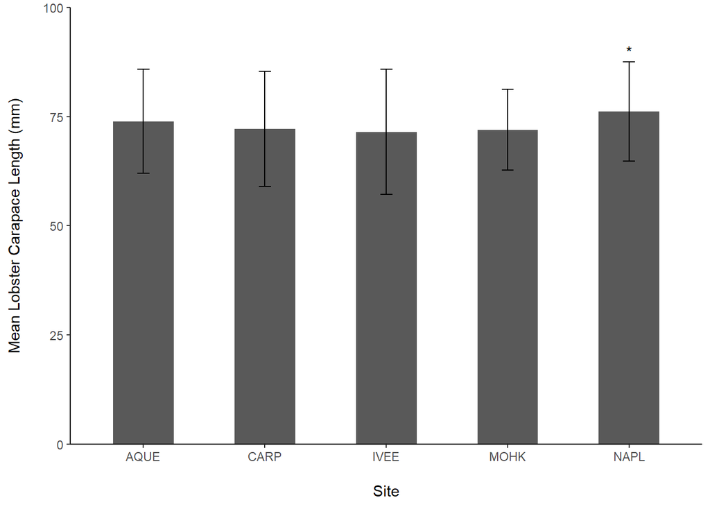

**Figure 1. Lobster carapace length for five sites in 2017.** Mean lobster carapace length (mm) for sites AQUE (n = 67), CARP (n = 705), IVEE (n = 606), MOHK (n = 178), and NAPL (n = 112) in Santa Barbara County in 2017. Error bars indicate +/- 1 standard deviation. *Asterisk or letters indicate values that do/do not differ significantly* (by one-way ANOVA with Tukey’s HSD; F(4,1663) = 3.42, $p$ = 0.0085) with $\alpha$ = 0.05 for all post-hoc pairwise comparison.

```r
### 3. Change in lobster size at MPA and non-MPA sites between 2012 and 2017
# MPA = NAPL, IVEE; non-MPA = AQUE, CARP, MOHK
# Summary Statistics
# Tests for normality
# Hypothesis Test

# Question 1: At MPA sites, how do lobster sizes in 2012 and 2017 compare?

# Question 2: At non-MPA sites, how do lobster sizes in 2012 and 2017 compare?
```

### 4. Proportions of “legal” lobsters at 5 sites in 2017

```r
### 4. Proportions of "legal" lobsters at 5 sites in 2017
# Legal minimum carapace size is 82.6 mm
# Chi-square test

# Question 1: What proportion of observed lobsters at each site are above the legal minumum?

ivprop <-size_2017 %>%
  filter(SITE == "IVEE")
prop(ivprop, SIZE > 82.6)
```

```
## [1] 0.2145
```

```r
naprop <-size_2017 %>%
  filter(SITE == "NAPL")
prop(naprop, SIZE > 82.6)
```

```
## [1] 0.3304
```

```r
aqprop <-size_2017 %>%
  filter(SITE == "AQUE")
prop(aqprop, SIZE > 82.6)
```

```
## [1] 0.2388
```

```r
caprop <-size_2017 %>%
  filter(SITE == "CARP")
prop(caprop, SIZE > 82.6)
```

```
## [1] 0.2539
```

```r
moprop <-size_2017 %>%
  filter(SITE == "MOHK")
prop(moprop, SIZE > 82.6)
```

```
## [1] 0.1348
```

```r
# Question 2: Does that proportion differ significantly across 5 sites?

# H0: There is no notable difference between the proportion of lobsters above the legal size limit between the five sites.
# HA: There is a notable difference between the proportion of lobsters above the legal size limit between the five sites.

chisq.test(c(.2145, .3304, .2388, .2539, .1348))
```

```
##
##  Chi-squared test for given probabilities
##
## data:  c(0.2145, 0.3304, 0.2388, 0.2539, 0.1348)
## X-squared = 0.085004, df = 4, p-value = 0.9991
```